# Predicting the Cost of Health Insurance

Pstats 131 Habib Mahmud

2024-03-23

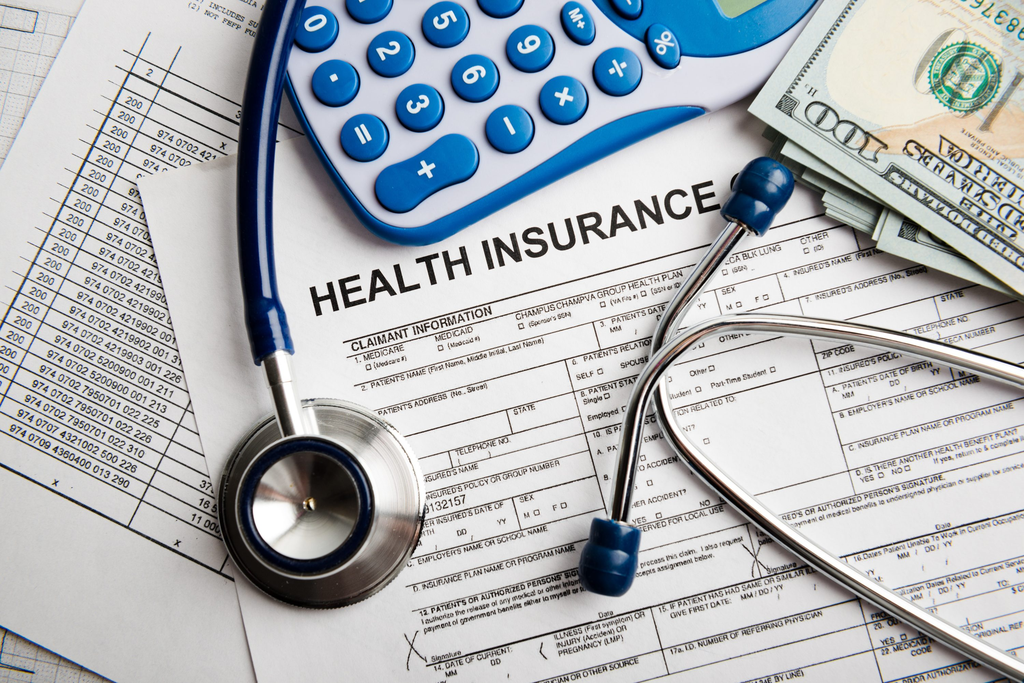

# Introduction

## What is Health Insurance??

Health Insurance is wide known type of service that all citizen must have. It is a financial backup that helps people cover medical bills by paying a monthly premium. Insurance covers basics like physical exams and medicine, but in case of something life-threatening happens the bills of the operation will be covered by a insurance company leaving you only to pay a reasonably reduced price. Insurance cost usually depends on the person and their health.

## WHY?? What the purpose of this Project?

Health Insurance company determine the price of your monthly premium based on you some categories, like age, and smoking. Even though Health Insurance is mandatory for U.S. Citizens, it would be important to know what the average or what their cost should be based on their personal attributes. Knowing the cost of health insurance can help plan the monthly budget and how it could be distributed. There are multiple reasons for knowing the personal cost of insurance, which is why I was interested in analyzing this dataset.

## What this project will be doing?

I have decided to take in the factors of age, sex, bmi (body mass index or weight/(height^2)), children, smoker, region, and charges to determine how these factors affect the charge variable and see if we can create a prediction on the cost based on peoples’ personal attributes.

# Getting Ready to Analyze

## Loading all necessary packages

```r
# Loading all necessary packages
library(tidyverse)
library(tidymodels)
library(janitor)
library(corrplot)
library(corrr)
library(yardstick)
library(kknn)
library(glmnet)
library(ranger)
library(vip)

insurance_data <- read.csv("data/insurance.csv")
head(insurance_data)
```

```
##   age    sex    bmi children smoker    region   charges
## 1  19 female 27.900        0    yes southwest 16884.924
## 2  18   male 33.770        1     no southeast  1725.552
## 3  28   male 33.000        3     no southeast  4449.462
## 4  33   male 22.705        0     no northwest 21984.471
## 5  32   male 28.880        0     no northwest  3866.855
## 6  31 female 25.740        0     no southeast  3756.622
```

This [dataset](https://www.kaggle.com/datasets/teertha/ushealthinsurancedataset/data) is provided by ANIRBAN DATTA, from the website Kaggle. This dataset was created for the purpose of analyzing and creating models for predicting Insurance Premium Charges.

## Organizing and Cleaning the Data

As you can see from the head of the data we have 3 variables that we would want to convert to factors.

```r
insurance_data$sex <- as.factor(insurance_data$sex)
insurance_data$smoker <- as.factor(insurance_data$smoker)
insurance_data$region <- as.factor(insurance_data$region)

head(insurance_data)
```

```
##   age    sex    bmi children smoker    region   charges
## 1  19 female 27.900        0    yes southwest 16884.924
## 2  18   male 33.770        1     no southeast  1725.552
## 3  28   male 33.000        3     no southeast  4449.462
## 4  33   male 22.705        0     no northwest 21984.471
## 5  32   male 28.880        0     no northwest  3866.855
## 6  31 female 25.740        0     no southeast  3756.622
```

Let’s run a summary to see if the factor did its job properly.

```r
summary(insurance_data)
```

```
##       age            sex           bmi           children     smoker
##  Min.   :18.00   female:662   Min.   :15.96   Min.   :0.000   no :1064
##  1st Qu.:27.00   male  :676   1st Qu.:26.30   1st Qu.:0.000   yes: 274
##  Median :39.00                Median :30.40   Median :1.000
##  Mean   :39.21                Mean   :30.66   Mean   :1.095
##  3rd Qu.:51.00                3rd Qu.:34.69   3rd Qu.:2.000
##  Max.   :64.00                Max.   :53.13   Max.   :5.000
##        region       charges
##  northeast:324   Min.   : 1122
##  northwest:325   1st Qu.: 4740
##  southeast:364   Median : 9382
##  southwest:325   Mean   :13270
##                  3rd Qu.:16640
##                  Max.   :63770
```

As we can see it worked as planned.

## Missing Data

Now let us check to see if there is any missing data.

```r
colSums(is.na(insurance_data))
```

```
##      age      sex      bmi children   smoker   region  charges
##        0        0        0        0        0        0        0
```

Perfect there is no missing data. Now we can move onto the Exploratory Data Analysis.

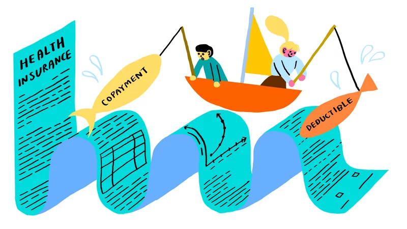

# Visual EDA

Now let’s switch to seeing some preliminary visual data of the effects of specific attributes on the charge variable.

## BMI

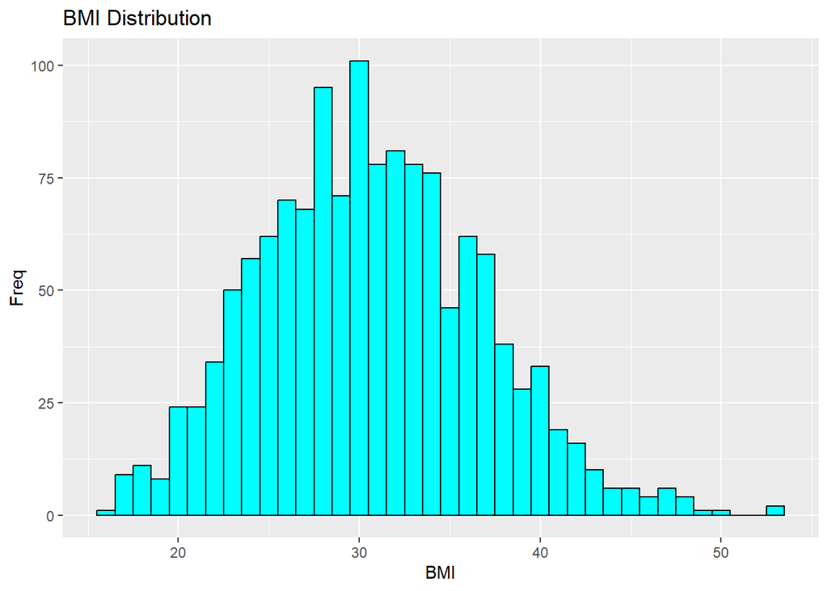

```r
ggplot(insurance_data, aes(x = bmi)) +
  geom_histogram(binwidth = 1, color = "black", fill = "cyan") +
  labs(title = "BMI Distribution",
       x = "BMI",
       y = "Freq")
```

As we can see from the graph the BMI of the people in this dataset mostly range from 20 to 40 which according to National Heart, Lung, and Blood Institute is normal weight to obesity. So our data here captures a wide variety of people. Link to Website [here](https://www.nhlbi.nih.gov/health/educational/lose_wt/BMI/bmicalc.htm)

## Age vs Charges

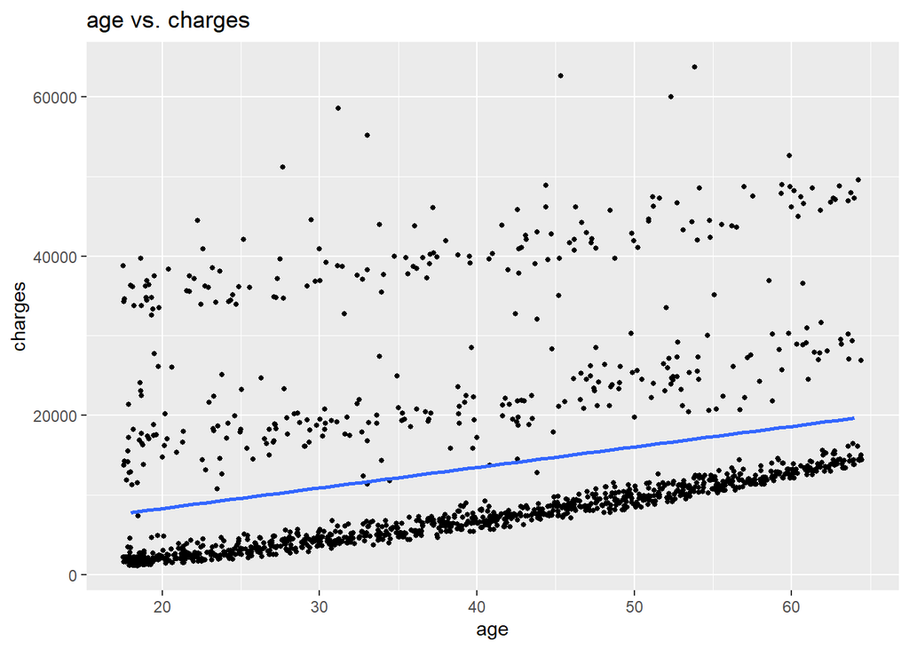

```r
insurance_data %>%
  ggplot(aes(x=age, y=charges)) +
  geom_jitter(width = 0.5, size = 1) +
  geom_smooth(method = "lm", se =F) +
  labs(title = "age vs. charges")
```

It is quite obvious that there is a relationship between age and charges as we see from the graph. As a person ages we see that their premium cost goes up. Other variable within the chart with higher charges might be due to BMI or Smoker, so let’s check that out next.

## BMI VS Charges

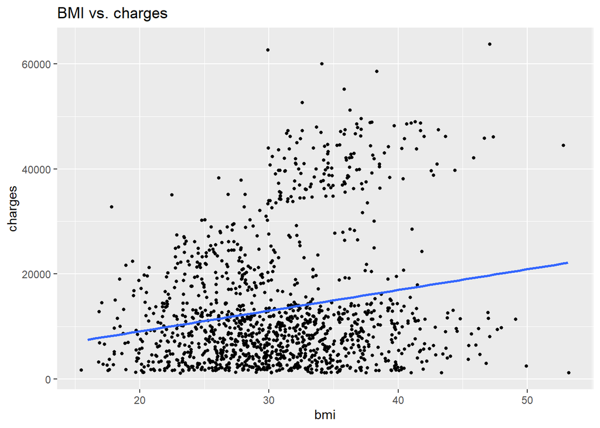

```r
insurance_data %>%
  ggplot(aes(x=bmi, y=charges)) +
  geom_jitter(width = 0.5, size = 1) +
  geom_smooth(method = "lm", se =F) +
  labs(title = "BMI vs. charges")
```

As I suspected, there is also a correlation between BMI and the rate of charges increasing. Even though it seems a little weak, we can see that there may be another factor that plays a role in affecting the charge portion.

## Smoker On Charges

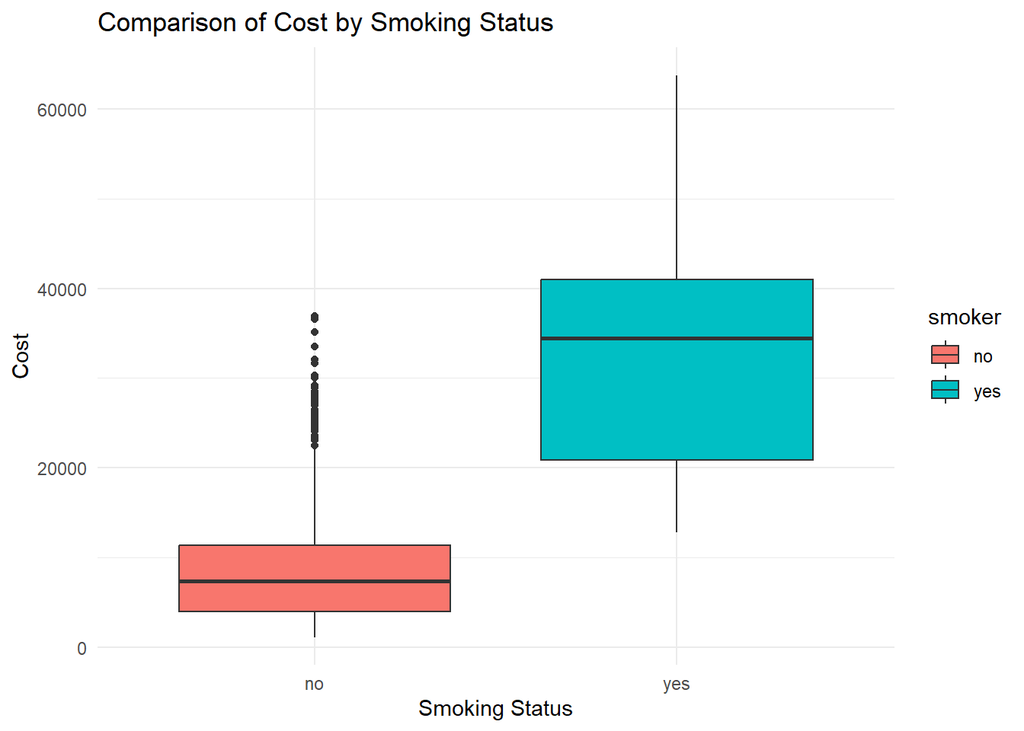

```r
insurance_data %>%
  ggplot(aes(x = smoker, y = charges, fill = smoker)) +
  geom_boxplot() +
  labs(title = "Comparison of Cost by Smoking Status",
       x = "Smoking Status",
       y = "Cost") +
  theme_minimal()
```

While there may be some outliers, we see that clearly there is a very large affect of whether or not the person is a smoker and the cost of their premiums on their insurance.

## Correlation Plot

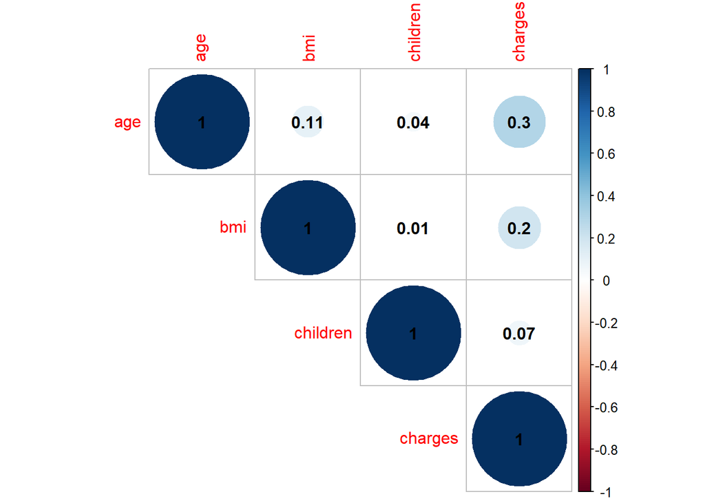

[figure not shown]

```r
insurance_temp <- na.omit(insurance_data)
insurance_temp <- insurance_temp %>% select_if(is.numeric)
ins_cor <- cor(insurance_temp)
ins_corrplot <- corrplot(ins_cor, method = "circle", type="upper",addCoef.col = 1)
```

The correlation graph confirms my precognition that BMI, and Age affect the charges variable. Based on my research from all the data charts we see that BMI, Age, and smoking is main cause of why a person’s cost of premiums could be so high.

# Setting Up the Model

Now that we have a general sense of how our data set is and the intricacies of the relationship within the data we can know focus on creating models. Before we begin we should have a set seed, which lets us remember our data and how it was analyze so that we can repeat the process if we wanted to try the experiment again with the same results./

```r
set.seed(131)
```

## Splitting the Data

Before we begin we to be able to have two separate dataset, one for training the model and one for testing the model. This is a key step that must be taken in order to create a machine learning model. The training data will be used so that we can have our model adjust to our specific criteria. The testing model is done to see how accurate our training model did. Once we have done the fitting we see which model performed the best based on the RMSE (Root Mean Square Error for regression). I will be doing a 70 30 split of the data, which means that 70% of the data will be allocated for training and 30% for testing. I find that this is a great balance, since we will have enough data to train and smaller but enough data to test. I will be stratifying on charges since we want to have a equal distribution of that variable throughout our training and test. Also we want to predict on the charge variable./

```r
insurance_split <- insurance_data %>%
  initial_split(prop = 0.70, strata = charges)
insurance_train <- training(insurance_split)
insurance_test <- testing(insurance_split)
```

Before we move on we should if the split occurred properly.

```r
dim(insurance_train)
```

```
## [1] 934   7
```

```r
dim(insurance_test)
```

```
## [1] 404   7
```

we see that the data was split properly and now we can move on.

## Recipe Creation

```r
insurance_recipe <- recipe(charges ~ bmi + age + smoker + children, data = insurance_data) %>%
  step_dummy(all_nominal()) %>%
  step_center(all_predictors()) %>%
  step_scale(all_predictors())
```

## K-Fold Validation

We will stratify on the variable Charges as we did before.

```r
insurance_fold <- vfold_cv(insurance_train, v = 10, strata = charges)
```

# Model Building

Now we will build our model. We will be using five different models: Linear Regression, Ridge Regression, K nearest neighbor, Elastic Net, and finally Random Forest. To test its performance we will using Root Mean Squared Error, or RMSE, as a metric in determining which model performed the best. The result of RMSE gives us a quantifiable way to determine the accuracy and precision of our model’s prediction. It’s done by measuring the average difference between the predicted values and the true values./

## Fitting the Models

now we setup the models and will be consistently incorporate the seed to avoid any errors in the computation.

```r
set.seed(131)
# Linear Regression
lm_model <- linear_reg() %>%
  set_engine("lm")

# Ridge Regression
ridge_spec <- linear_reg(mixture = 0,
                         penalty = tune()) %>%
  set_mode("regression") %>%
  set_engine("glmnet")

# K Nearest Neighbor
knn_model <- nearest_neighbor(neighbors = tune()) %>%
  set_mode("regression") %>%
  set_engine("kknn")

# Elastic Net
elastic_spec <- linear_reg(penalty = tune(),
                           mixture = tune()) %>%
  set_mode("regression") %>%
  set_engine("glmnet")

# Random Forest
rf_spec <- rand_forest(mtry = tune(),
                       trees = tune(),
                       min_n = tune()) %>%
  set_engine("ranger", importance = "impurity") %>%
  set_mode("regression")
```

/

Now we set up the work flow for each model and recipe.

```r
set.seed(131)
# Linear Regression
lm_workflow <- workflow() %>%
  add_model(lm_model) %>%
  add_recipe(insurance_recipe)

# Ridge Regression
ridge_workflow <- workflow() %>%
  add_recipe(insurance_recipe) %>%
  add_model(ridge_spec)

# K Nearest Neighbor
knn_workflow <- workflow() %>%
  add_model(knn_model) %>%
  add_recipe(insurance_recipe)

# Elastic Net
elastic_workflow <- workflow() %>%
  add_recipe(insurance_recipe) %>%
  add_model(elastic_spec)

# Random Forest
rf_workflow <- workflow() %>%
  add_recipe(insurance_recipe) %>%
  add_model(rf_spec)
```

Now lets set up the tuning grids for all models, which is essentially a set of different parameters that help us get the optimal set of hyper parameter, which will output the highest performing model.

```r
lm_grid <- grid_regular(penalty(range = c(0,5)), levels = 50)
knn_grid <- grid_regular(neighbors(range = c(1,10)), levels = 10)
elastic_grid <- grid_regular(penalty(),
                             mixture(range = c(0, 1)),
                             levels = 10)
rf_parameter_grid <- grid_regular(mtry(range = c(1, 4)),
                                  trees(range = c(200,900)),
                                  min_n(range = c(5,20)), levels = 8)
```

## Tuning

Now that we have our grid we can use this to tune our models using your insurance_fold dataset.

```r
set.seed(131)

# Ridge Regression
ridge_tune <- tune_grid(
  ridge_workflow,
  resamples = insurance_fold,
  grid = lm_grid
)

# K Nearest Neighbor
knn_tune <- tune_grid(
  knn_workflow,
  resamples = insurance_fold,
  grid = knn_grid
)

#Elastic Net
#elastic_tune <- tune_grid(
  #elastic_workflow,
  #resamples = insurance_fold,
  #grid = elastic_grid
#)

#Random Forest
#rf_tune_res <- tune_grid(
 #rf_workflow,
 #resamples = insurance_fold,
 #grid = rf_parameter_grid
#)


save(ridge_tune, file = "rdafiles/ridge_tune.rda")
save(knn_tune, file = "rdafiles/knn_tune.rda")
#save(elastic_tune, file = "rdafiles/elastic_tune.rda")
#save(rf_tune_res, file = "rdafiles/rf_tune_res.rda")
```

Now that we have the Elastic Net and Random Forest Models save we can just load it again to save time.

```r
load("rdafiles/ridge_tune.rda")
load("rdafiles/knn_tune.rda")
load("rdafiles/elastic_tune.rda")
load("rdafiles/rf_tune_res.rda")
```

# Model Results

## Testing Models for the Lowest RMSE

```r
# Linear Regression
lm_fit <- fit_resamples(lm_workflow,
                        resamples = insurance_fold)
lm_rmse <- collect_metrics(lm_fit) %>% filter(.metric == "rmse")

# K Nearest Neighbor
knn_rmse <- collect_metrics(knn_tune) %>% arrange(mean) %>% filter(.metric == "rmse")
best_knn <- knn_rmse$mean[which.min(knn_rmse$mean)]

# Ridge Regression
ridge_rmse <- collect_metrics(ridge_tune) %>% filter(.metric == "rmse")
best_ridge <- ridge_rmse$mean[which.min(ridge_rmse$mean)]

# Elastic Net
elastic_rmse <- collect_metrics(elastic_tune) %>% arrange(mean) %>% filter(.metric == "rmse")
best_elastic <- elastic_rmse$mean[which.min(elastic_rmse$mean)]

# Random Forest
rf_rmse <- collect_metrics(rf_tune_res) %>% arrange(mean) %>% filter(.metric == "rmse")
best_rf <- rf_rmse$mean[which.min(rf_rmse$mean)]
```

## Compare the Model

```r
compare <- tibble(Model = c("Linear Regression", "Ridge Regression",
                            "K Nearest Neighbors", "Elastic Net",
                            "Random Forest"),
                  RMSE = c(lm_rmse$mean, best_ridge, best_knn, best_elastic,
                                        best_rf))

compare %>% arrange(RMSE)
```

```
## # A tibble: 5 × 2
##   Model                RMSE
##   <chr>               <dbl>
## 1 Random Forest       4583.
## 2 K Nearest Neighbors 5041.
## 3 Elastic Net         6085.
## 4 Linear Regression   6171.
## 5 Ridge Regression    6221.
```

/ As we can see Random Forest performed the best out of all 5 of the models, thus we will explore more into it. We also see that K Nearest Neighbor came in second to Random Forest./

## AutoPlots

### KNN Plot

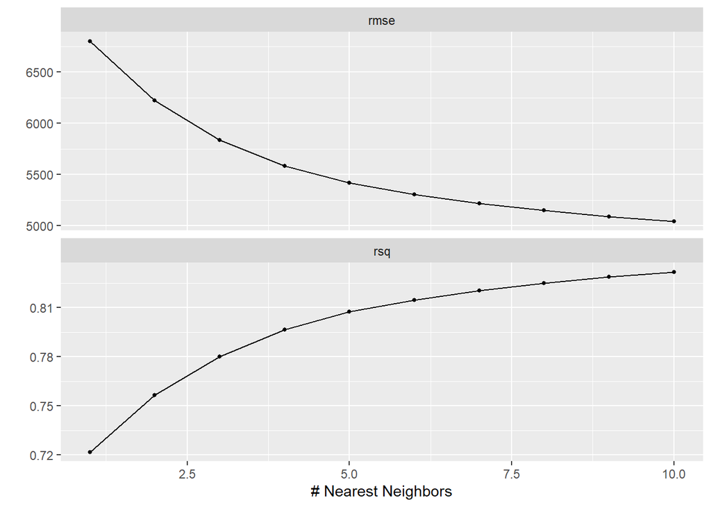

```r
autoplot(knn_tune)
```

### Elastic Plot

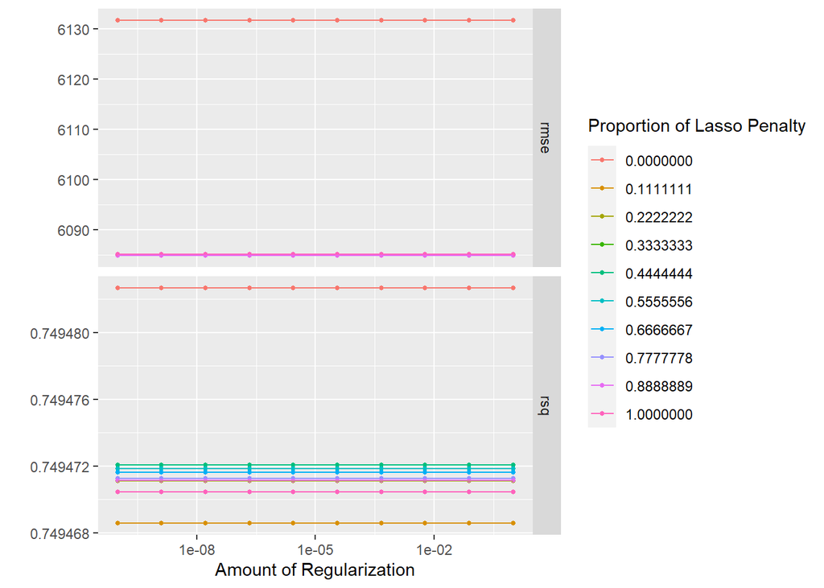

```r
autoplot(elastic_tune)
```

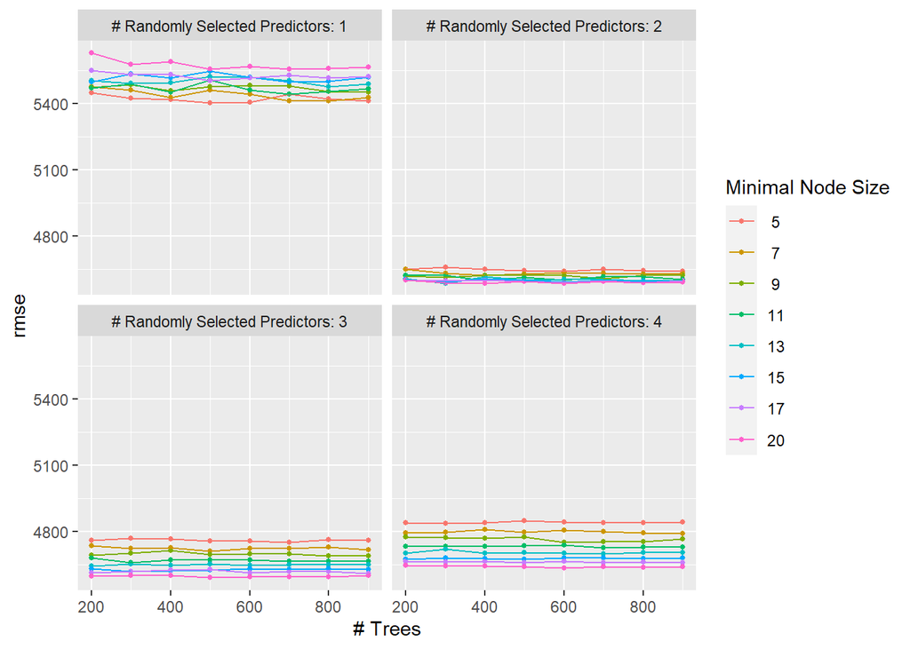

```r
autoplot(rf_tune_res, metric="rmse")
```

# Results From the Best Model

## Fitting the Data

Now we will input the testing data to the best model./

```r
best_rf_train <- select_best(rf_tune_res, metric = 'rmse')
final_rf_model <- finalize_workflow(rf_workflow, best_rf_train)
final_rf_model <- fit(final_rf_model, data = insurance_train)
```

## Which variables are importants??

[figure not shown]

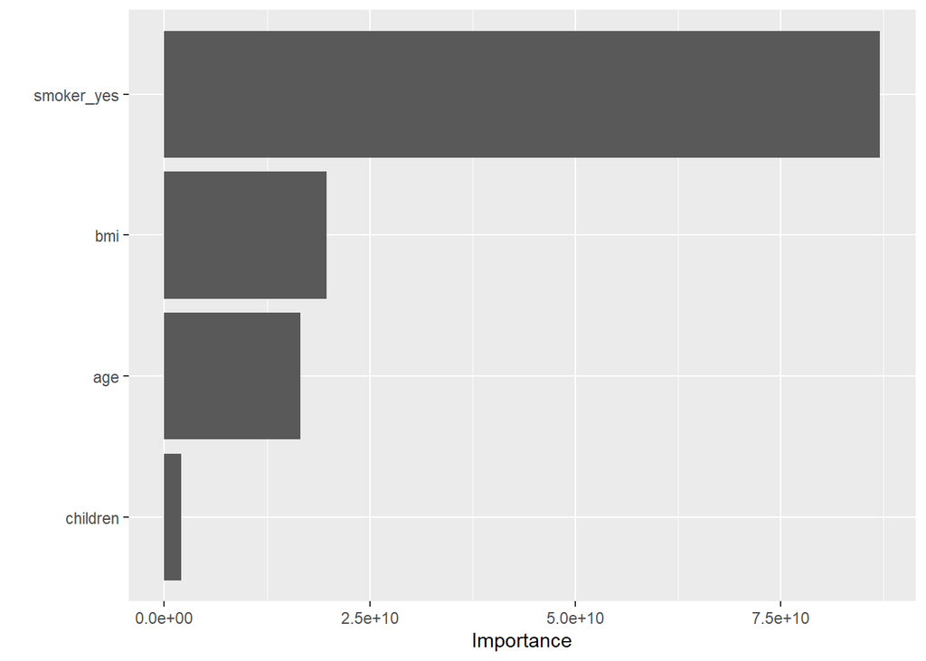

```r
final_rf_model %>%
  extract_fit_parsnip() %>%
  vip()
```

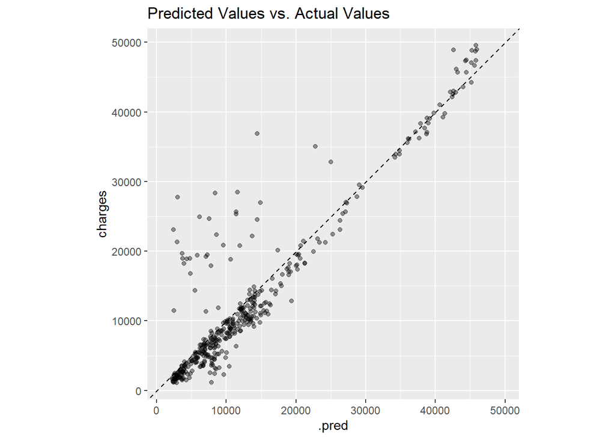

```r
insurance_tib <- predict(final_rf_model, new_data = insurance_test %>% select(-charges))
insurance_tib <- bind_cols(insurance_tib, insurance_test %>% select(charges))

insurance_tib %>%
  ggplot(aes(x = .pred, y = charges)) +
  geom_point(alpha = 0.4) +
  geom_abline(lty = 2) +
  coord_obs_pred() +
  labs(title = "Predicted Values vs. Actual Values")
```

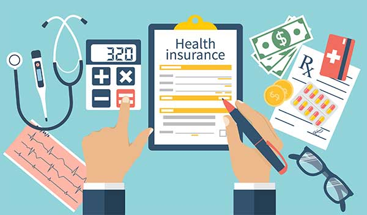

# Conclusion

After cleaning the data, splitting into a train and test set, creating models, and training the model, we see that the Random Forest Model turned out to be the best model. It was able to very accurately predict the actual data using the same parameters. We also see, based on the low RMSE, that K-Nearest Neighbor was a viable option for our model.

In the end, we see that the Random Forest model was trained to be able to predict a charge based on a person’s BMI, Age, and whether or not they smoked. Using these attributes our model was able to as I said before predict very well the testing data. I would use this model as a base line to tell how much a person’s insurance might cost, but I would not solely base it on this model. Our model was very simplistic, and does not account for environmental factors, which can play a huge role in terms of cost of premiums.

I really did not encounter any major problems. My dataset was very clean and there was no missing data which made my job a lot easier. My model came out just as I expected it to as well.

# Sources

[Link](https://www.kaggle.com/datasets/teertha/ushealthinsurancedataset/data) to the dataset provided by ANIRBAN DATTA, from the website Kaggle. For organization and format I used the Pokemon Example in the Final Project Examples.